# Module 14

# Basic Categorical Data Analysis and ANOVA

## Preliminaries

- Install these packages in *R*: {curl}, {dplyr}

## Objectives

> In this module, we examine how simple linear regression can be applied to datasets where our predictor variable is discrete or categorical rather than continuous. Indeed, we will see that one- and two-way analysis of variance (ANOVA) are specific applications of simple linear regression. We also look at other methods for basic statistical analysis of categorical data.

## Categorical Predictors in Regression

Thus far we have used simple linear regression models involving continuous explanatory variables, but we can also use a discrete or categorical explanatory variable, made up of 2 or more groups that are coded as "factors" (i.e., we use integer values from 1 to *k* discrete groups as dummy values for our categorical variables). Let's load in our zombie data again, but this time we specify `stringsAsFactors = TRUE` and then look at the class of the variable "gender".

```r
> library(curl)
> f <- curl("https://raw.githubusercontent.com/difiore/ADA2016/master/zombies.csv")
> z <- read.csv(f, header = TRUE, sep = ",", stringsAsFactors = TRUE)
> class(z$gender)
```

```
## [1] "factor"
```

```r
> summary(z$gender)
```

```
## Female   Male
##    494    506
```

As with our prior simple regression analysis, we want to evalute the effect of a predictor variable on a response variable, say "height", but this time we want our predictor to be the discrete variable "sex" rather than a continuous one. We can start off by plotting "height" by "sex" using the same formula notation we have been using.

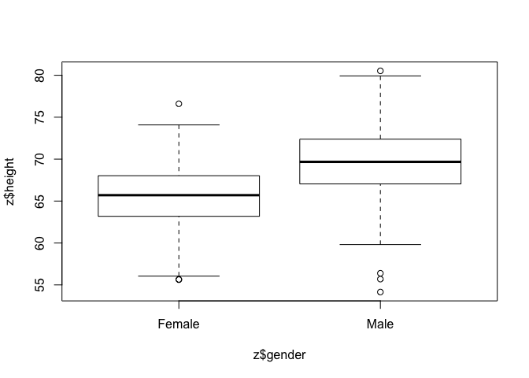

```r
> plot(z$height ~ z$gender)
```

Based on our plot, there indeed seems to be a difference in height between males and females. We can test this directly using linear regression (and, recall, we already know another way to test this, using z or t tests to compare means).

```r
> m <- lm(data = z, height ~ gender)
> summary(m)
```

```
##
## Call:
## lm(formula = height ~ gender, data = z)
##
## Residuals:
##      Min       1Q   Median       3Q      Max
## -15.4642  -2.4861   0.0876   2.5425  11.0065
##
## Coefficients:
##             Estimate Std. Error t value Pr(>|t|)
## (Intercept)  65.5983     0.1717  382.13   <2e-16 ***
## genderMale    4.0154     0.2413   16.64   <2e-16 ***
## ---
## Signif. codes:  0 '***' 0.001 '**' 0.01 '*' 0.05 '.' 0.1 ' ' 1
##
## Residual standard error: 3.815 on 998 degrees of freedom
## Multiple R-squared:  0.2172, Adjusted R-squared:  0.2164
## F-statistic: 276.9 on 1 and 998 DF,  p-value: < 2.2e-16
```

If we take a look at the `summary()` of our model, **m**, we see the same kind of table of results we have seen before, but because the predictor variable in this case is a factor vector instead of a numeric vector, the coefficients are reported and interpreted a bit differently. The coefficient for the intercept, i.e., *β*<sub>0</sub>, reflects the estimate of the mean height for the first of our level variables.

```r
> levels(z$gender)
```

```
## [1] "Female" "Male"
```

In this case, the **p** value associated with the **t** statistic for *β*<sub>1</sub> is extremely low, so we conclude that "gender" has a significant effect on height.

We can easily `relevel()` what is the baseline group. The result is very similar, but the sign of *β*<sub>1</sub> is changed.

```r
> z$gender <- relevel(z$gender, ref = "Male")
> m <- lm(data = z, height ~ gender)
> summary(m)
```

```
##
## Call:
## lm(formula = height ~ gender, data = z)
##
## Residuals:
##      Min       1Q   Median       3Q      Max
## -15.4642  -2.4861   0.0876   2.5425  11.0065
##
## Coefficients:
##              Estimate Std. Error t value Pr(>|t|)
## (Intercept)   69.6137     0.1696  410.42   <2e-16 ***
## genderFemale  -4.0154     0.2413  -16.64   <2e-16 ***
## ---
## Signif. codes:  0 '***' 0.001 '**' 0.01 '*' 0.05 '.' 0.1 ' ' 1
##
## Residual standard error: 3.815 on 998 degrees of freedom
## Multiple R-squared:  0.2172, Adjusted R-squared:  0.2164
## F-statistic: 276.9 on 1 and 998 DF,  p-value: < 2.2e-16
```

The last line of the `summary()` output shows the results of the global test of significance of the regression model based on an F statistic compared to an F distribution with, in this case, 1 and 998 degrees of freedom.

```r
> p <- 1 - pf(276.9, df1 = 1, df2 = 998)
```

We can extend this approach to the case where we have more than two categories for a variable... in this case we need to dummy code our factor variable into multiple binary variables. *R* takes care of this for us automatically, but it is good to recognize the procedure.

Let's explore this by recoding the variable "major" into four levels. We first create a new variable name.

```r
> z$occupation <- "temp"
```

We can use the `unique()` or `levels()` function to list all of the different majors in our dataset. The latter does this alphabetically. The `row()` command returns an index of row numbers, which we can then use to recode "major" into our new variable.

```r
> unique(z$major)
```

```
##  [1] medicine/nursing
##  [2] criminal justice administration
##  [3] education
##  [4] energy studies
##  [5] logistics
##  [6] psychology
##  [7] botany
##  [8] communication
##  [9] military strategy
## [10] economics
## [11] mechanical engineering
## [12] physical education
## [13] philosophy
## [14] biology
## [15] applied sciences
## [16] animal husbandry
## [17] agricultural sciences
## [18] culinart services
## [19] city planning
## [20] integrated water resources management
## [21] pharmacology
## [22] environmental science
## [23] human services
## [24] epidemiology
## [25] business administration
## [26] architecture
## 26 Levels: agricultural sciences animal husbandry ... psychology
```

```r
> levels(z$major)
```

```
##  [1] "agricultural sciences"
##  [2] "animal husbandry"
##  [3] "applied sciences"
##  [4] "architecture"
##  [5] "biology"
##  [6] "botany"
##  [7] "business administration"
##  [8] "city planning"
##  [9] "communication"
## [10] "criminal justice administration"
## [11] "culinart services"
## [12] "economics"
## [13] "education"
## [14] "energy studies"
## [15] "environmental science"
## [16] "epidemiology"
## [17] "human services"
## [18] "integrated water resources management"
## [19] "logistics"
## [20] "mechanical engineering"
## [21] "medicine/nursing"
## [22] "military strategy"
## [23] "pharmacology"
## [24] "philosophy"
## [25] "physical education"
## [26] "psychology"
```

```r
> row(data.frame(levels(z$major)))
```

```
##       [,1]
##  [1,]    1
##  [2,]    2
##  [3,]    3
##  [4,]    4
##  [5,]    5
##  [6,]    6
##  [7,]    7
##  [8,]    8
##  [9,]    9
## [10,]   10
## [11,]   11
## [12,]   12
## [13,]   13
## [14,]   14
## [15,]   15
## [16,]   16
## [17,]   17
## [18,]   18
## [19,]   19
## [20,]   20
## [21,]   21
## [22,]   22
## [23,]   23
## [24,]   24
## [25,]   25
## [26,]   26
```

```r
> z$occupation[row(data.frame(levels(z$major))) %in% c(1, 2, 3, 5, 6, 14, 15,
+     16, 18, 21, 23)] <- "natural science"
> z$occupation[row(data.frame(levels(z$major))) %in% c(7, 8, 12, 17, 19, 22)] <- "logistics"
> z$occupation[row(data.frame(levels(z$major))) %in% c(4, 18, 20)] <- "engineering"
> z$occupation[row(data.frame(levels(z$major))) %in% c(9, 10, 11, 13, 24, 25,
+     26)] <- "other"
> z$occupation <- as.factor(z$occupation)
> levels(z$occupation)
```

```
## [1] "engineering"     "logistics"       "natural science" "other"
```

```r
> z$occupation <- relevel(z$occupation, ref = "natural science")
> levels(z$occupation)
```

```
## [1] "natural science" "engineering"     "logistics"       "other"
```

Again, we can plot our variable by group and run a multilevel linear regression. Each *β* estimate reflects the difference from the estimated mean for the reference level. The `lm()` function also returns the results of the global significance test of our model.

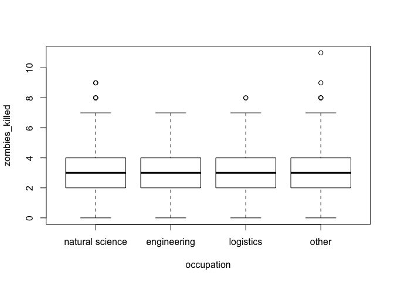

```r
> plot(data = z, zombies_killed ~ occupation)
```

```r
> m <- lm(data = z, zombies_killed ~ occupation)
> summary(m)
```

```
##
## Call:
## lm(formula = zombies_killed ~ occupation, data = z)
##
## Residuals:
##     Min      1Q  Median      3Q     Max
## -3.0234 -1.0234 -0.0234  0.9827  7.9926
##
## Coefficients:
##                        Estimate Std. Error t value Pr(>|t|)
## (Intercept)            3.023377   0.089172  33.905   <2e-16 ***
## occupationengineering -0.223377   0.185935  -1.201    0.230
## occupationlogistics   -0.006061   0.145616  -0.042    0.967
## occupationother       -0.015942   0.139040  -0.115    0.909
## ---
## Signif. codes:  0 '***' 0.001 '**' 0.01 '*' 0.05 '.' 0.1 ' ' 1
##
## Residual standard error: 1.75 on 996 degrees of freedom
## Multiple R-squared:  0.001582,   Adjusted R-squared:  -0.001426
## F-statistic: 0.526 on 3 and 996 DF,  p-value: 0.6645
```

```r
> p <- 1 - pf(0.526, df1 = 3, df2 = 996)  # F test
> p
```

```
## [1] 0.6644926
```

In this case, we see no significant effect of major on zombie killing proficiency.

## One-Way ANOVA

Regression with a single categorical predictor run as we have just done above is exactly equivalent to a "one-way" or "one-factor" analysis of variance, or ANOVA. That is, ANOVA is just one type of special case of least squares regression. We can thus run an ANOVA with one line in *R*. Compare the results presented in the `summary()` output table from an ANOVA with that from the global test reported in `summary()` from `lm()`

```r
> m <- aov(data = z, zombies_killed ~ occupation)
> summary(m)
```

```
##              Df Sum Sq Mean Sq F value Pr(>F)
## occupation    3    4.8   1.610   0.526  0.665
## Residuals   996 3049.1   3.061
```

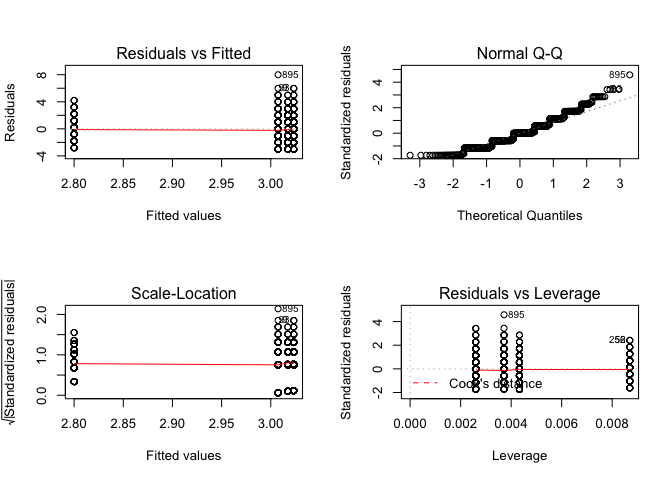

```r
> par(mfrow = c(2, 2))
> plot(m)
```

In general, in ANOVA and simple regression using a single categorical variable, we aim to test the *H*<sub>0</sub> that the means of a variable of interest do not differ among groups, i.e., that *μ*<sub>1</sub> = *μ*<sub>2</sub>... *μ*<sub>*k*</sub> are all equal. This is an extension of our comparison of two means that we did with z and t tests.

#### CHALLENGE:

```r
> library(curl)
> library(dplyr)
> f <- curl("https://raw.githubusercontent.com/difiore/ADA2016/master/gibbon-femurs.csv")
> d <- read.csv(f, header = TRUE, sep = ",", stringsAsFactors = TRUE)
> head(d)
```

```
##   id age    sex femur.length
## 1  1 inf female         7.28
## 2  2 inf   male         6.30
## 3  3 inf female         7.44
## 4  4 inf   male         8.69
## 5  5 inf female         9.13
## 6  6 inf   male         9.28
```

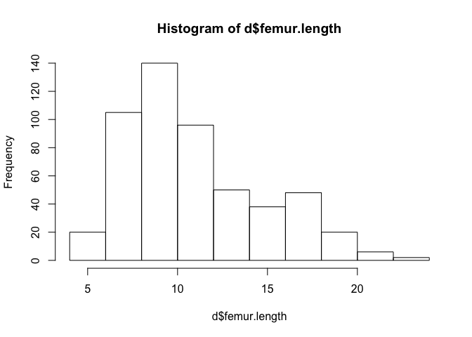

```r
> hist(d$femur.length)
```

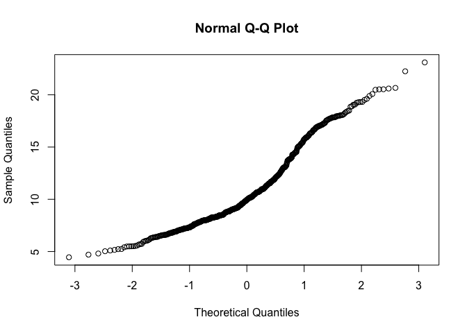

```r
> qqnorm(d$femur.length)
```

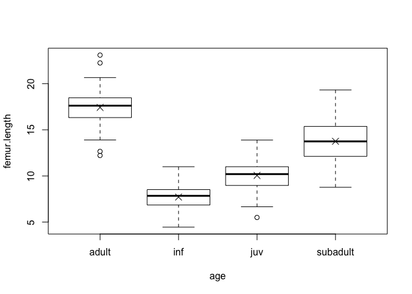

```r
> plot(data = d, femur.length ~ age)  # boxplot with median
> means <- summarise(group_by(d, age), mean(femur.length))  # calculate average by group
> points(1:4, means$`mean(femur.length)`, pch = 4, cex = 1.5)  # add means to plot
```

```r
> sds <- summarise(group_by(d, age), sd(femur.length))
> max(sds$`sd(femur.length)`)/min(sds$`sd(femur.length)`)  # check that variances are roughly equal (ratio of max/min is <2)
```

```
## [1] 1.767635
```

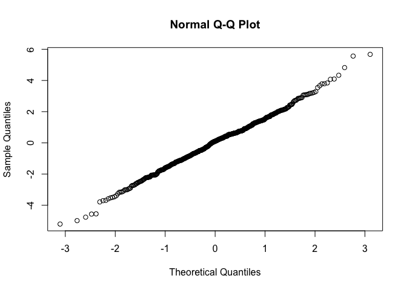

```r
> means.centered <- d$femur.length - means[as.numeric(d$age), 2]  # subtract relevnant group mean from each data point
> qqnorm(means.centered$`mean(femur.length)`)  # graphical tests for normality
```

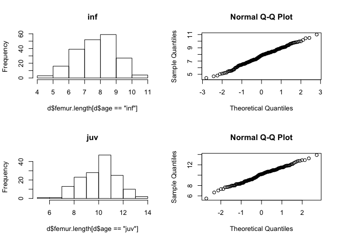

```r
> par(mfrow = c(2, 2))
> hist(d$femur.length[d$age == "inf"], main = "inf")
> qqnorm(d$femur.length[d$age == "inf"])
> hist(d$femur.length[d$age == "juv"], main = "juv")
> qqnorm(d$femur.length[d$age == "juv"])
```

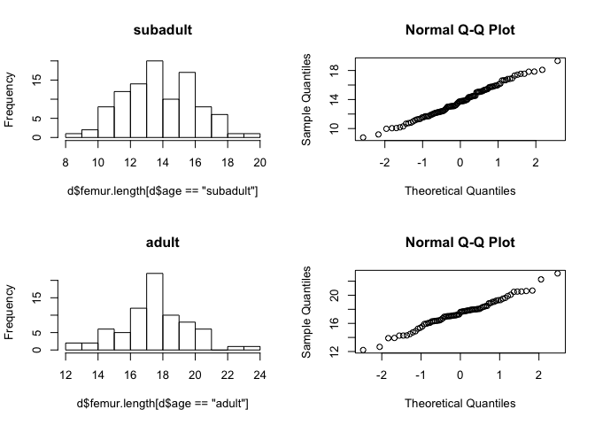

```r
> hist(d$femur.length[d$age == "subadult"], main = "subadult")
> qqnorm(d$femur.length[d$age == "subadult"])
> hist(d$femur.length[d$age == "adult"], main = "adult")
> qqnorm(d$femur.length[d$age == "adult"])
```

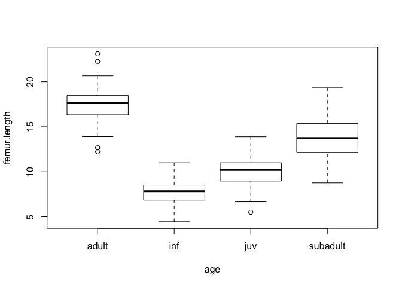

```r
> par(mfrow = c(1, 1))
> plot(data = d, femur.length ~ age)
```

```r
> m <- aov(data = d, femur.length ~ age)  # femur length related to age
> summary(m)
```

```
##              Df Sum Sq Mean Sq F value Pr(>F)
## age           3   6152  2050.6   735.8 <2e-16 ***
## Residuals   521   1452     2.8
## ---
## Signif. codes:  0 '***' 0.001 '**' 0.01 '*' 0.05 '.' 0.1 ' ' 1
```

```r
> m <- lm(data = d, femur.length ~ age)
> summary(m)
```

```
##
## Call:
## lm(formula = femur.length ~ age, data = d)
##
## Residuals:
##     Min      1Q  Median      3Q     Max
## -5.2052 -1.1104  0.1089  1.0396  5.6748
##
## Coefficients:
##             Estimate Std. Error t value Pr(>|t|)
## (Intercept)  17.4252     0.1928   90.39   <2e-16 ***
## ageinf       -9.7148     0.2260  -42.98   <2e-16 ***
## agejuv       -7.3741     0.2361  -31.23   <2e-16 ***
## agesubadult  -3.6688     0.2550  -14.39   <2e-16 ***
## ---
## Signif. codes:  0 '***' 0.001 '**' 0.01 '*' 0.05 '.' 0.1 ' ' 1
##
## Residual standard error: 1.669 on 521 degrees of freedom
## Multiple R-squared:  0.809,  Adjusted R-squared:  0.8079
## F-statistic: 735.8 on 3 and 521 DF,  p-value: < 2.2e-16
```

The Kruskal- Wallis test is a nonparametric alternative to one-way ANOVA that relaxes the need for normality in the distribution of data in each group (the different groups should still have roughly equal variances). Essentially, rather than testing the null hypothesis that the means for each group do not differ we are instead testing the null hypothesis that the medians do not differ. The test converts the continuous response variable to RANK (i.e., it does a uniform transformation) and then works with those ranks. The p value associated with the K-W test statistic is evaluated against a Chi-Square distribution.

```r
> m <- kruskal.test(data = d, femur.length ~ age)
> m
```

```
##
##  Kruskal-Wallis rank sum test
##
## data:  femur.length by age
## Kruskal-Wallis chi-squared = 407.13, df = 3, p-value < 2.2e-16
```

```r
> d <- arrange(d, femur.length)  # use {dplyr} to sort by femur.length
> d <- mutate(d, femur.rank = row(data.frame(d$femur.length)))  # use {dplyr} to add new variable of rank femur.length
> m <- kruskal.test(data = d, femur.rank ~ age)
> m
```

```
##
##  Kruskal-Wallis rank sum test
##
## data:  femur.rank by age
## Kruskal-Wallis chi-squared = 407.43, df = 3, p-value < 2.2e-16
```

## Multiple Factor ANOVA

Sometimes the data we are interested in is characterized by multiple grouping variables (e.g., age and sex). In the case of the gibbon femur length data, we are interested in the **main effect** of each factor on the variable of interest (e.g., do femur lengths vary by age or sex) while accounting for the effects of the other factor. We may also be interested in any **interactive effects** among factors. Thus, in multiple factor ANOVA we are interested in testing several null hypotheses simultaneously: [1] that each factor has no effect on the mean of our continuous reponse variable and [2] that there are no interactive effects of sets of factors on the mean of our continuous reponse variable.

Model description and testing for multiple ANOVA is a simple extension of the formula notation which we've used for single factors. First, though, let's quickly check that our groups have similar variance.

```r
> library(ggplot2)
> means <- summarise(group_by(d, age, sex), mean(femur.length))  # first we calculate averages by combination of factors
> means
```

```
## Source: local data frame [8 x 3]
## Groups: age [?]
##
##        age    sex `mean(femur.length)`
##     <fctr> <fctr>                <dbl>
## 1    adult female            16.715909
## 2    adult   male            18.431935
## 3      inf female             7.825049
## 4      inf   male             7.588763
## 5      juv female             9.976420
## 6      juv   male            10.138696
## 7 subadult female            12.673111
## 8 subadult   male            14.642727
```

```r
> sds <- summarise(group_by(d, age, sex), sd(femur.length))  # first we calculate averages by combination of factors
> sds
```

```
## Source: local data frame [8 x 3]
## Groups: age [?]
##
##        age    sex `sd(femur.length)`
##     <fctr> <fctr>              <dbl>
## 1    adult female           1.791199
## 2    adult   male           1.996978
## 3      inf female           1.220022
## 4      inf   male           1.309130
## 5      juv female           1.435525
## 6      juv   male           1.533014
## 7 subadult female           1.618919
## 8 subadult   male           2.296289
```

```r
> max(sds$`sd(femur.length)`)/min(sds$`sd(femur.length)`)  # check that variances in each group are roughly equal (ratio of max/min is <2)
```

```
## [1] 1.882171
```

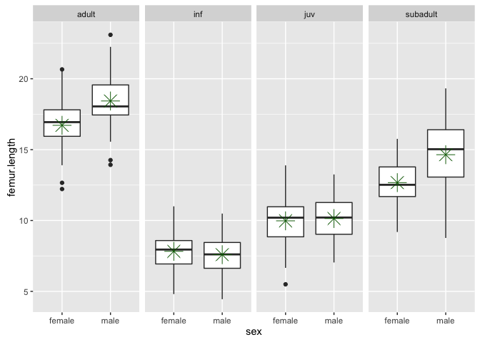

```r
> p <- ggplot(data = d, aes(y = femur.length, x = sex)) + geom_boxplot() + facet_wrap(~age,
+     ncol = 4)  # and let's plot what the data look like
> # p <- p + geom_point() # uncommenting this shows all points
> p <- p + stat_summary(fun.y = mean, colour = "darkgreen", geom = "point", shape = 8,
+     size = 6)
> p
```

If we look at each variable separately using ANOVA, we see there is an effect of age but not of sex.

```r
> summary(aov(data = d, femur.length ~ age))
```

```
##              Df Sum Sq Mean Sq F value Pr(>F)
## age           3   6152  2050.6   735.8 <2e-16 ***
## Residuals   521   1452     2.8
## ---
## Signif. codes:  0 '***' 0.001 '**' 0.01 '*' 0.05 '.' 0.1 ' ' 1
```

```r
> summary(aov(data = d, femur.length ~ sex))
```

```
##              Df Sum Sq Mean Sq F value Pr(>F)
## sex           1     28   28.33   1.956  0.163
## Residuals   523   7576   14.48
```

However, if we do a two-way ANOVA and consider the factors together, we see that there is still a main effect of age when taking sex into account **and** there is a main effect of sex when we take age into account.

```r
> m <- summary(aov(data = d, femur.length ~ age + sex))
> m
```

```
##              Df Sum Sq Mean Sq F value   Pr(>F)
## age           3   6152  2050.6   756.4  < 2e-16 ***
## sex           1     42    42.3    15.6 8.89e-05 ***
## Residuals   520   1410     2.7
## ---
## Signif. codes:  0 '***' 0.001 '**' 0.01 '*' 0.05 '.' 0.1 ' ' 1
```

To examine whether there is an interaction effect, we would modify our model formula a bit...

```r
> m <- aov(data = d, femur.length ~ age + sex + age:sex)  # : operator includes specific interaction terms
> summary(m)
```

```
##              Df Sum Sq Mean Sq F value   Pr(>F)
## age           3   6152  2050.6  816.35  < 2e-16 ***
## sex           1     42    42.3   16.84 4.72e-05 ***
## age:sex       3    111    37.0   14.73 3.21e-09 ***
## Residuals   517   1299     2.5
## ---
## Signif. codes:  0 '***' 0.001 '**' 0.01 '*' 0.05 '.' 0.1 ' ' 1
```

We could also use...

```r
> m <- aov(data = d, femur.length ~ age * sex)  # * operator includes all interaction terms
> summary(m)
```

```
##              Df Sum Sq Mean Sq F value   Pr(>F)
## age           3   6152  2050.6  816.35  < 2e-16 ***
## sex           1     42    42.3   16.84 4.72e-05 ***
## age:sex       3    111    37.0   14.73 3.21e-09 ***
## Residuals   517   1299     2.5
## ---
## Signif. codes:  0 '***' 0.001 '**' 0.01 '*' 0.05 '.' 0.1 ' ' 1
```

```r
> m <- lm(data = d, femur.length ~ age * sex)  # or using the lm() function...
> summary(m)
```

```
##
## Call:
## lm(formula = femur.length ~ age * sex, data = d)
##
## Residuals:
##     Min      1Q  Median      3Q     Max
## -5.8727 -1.0088  0.1336  1.0469  4.6773
##
## Coefficients:
##                     Estimate Std. Error t value Pr(>|t|)
## (Intercept)          16.7159     0.2389  69.960  < 2e-16 ***
## ageinf               -8.8909     0.2854 -31.148  < 2e-16 ***
## agejuv               -6.7395     0.2968 -22.706  < 2e-16 ***
## agesubadult          -4.0428     0.3360 -12.031  < 2e-16 ***
## sexmale               1.7160     0.3716   4.617 4.91e-06 ***
## ageinf:sexmale       -1.9523     0.4341  -4.498 8.48e-06 ***
## agejuv:sexmale       -1.5538     0.4534  -3.427 0.000658 ***
## agesubadult:sexmale   0.2536     0.4895   0.518 0.604641
## ---
## Signif. codes:  0 '***' 0.001 '**' 0.01 '*' 0.05 '.' 0.1 ' ' 1
##
## Residual standard error: 1.585 on 517 degrees of freedom
## Multiple R-squared:  0.8292, Adjusted R-squared:  0.8269
## F-statistic: 358.6 on 7 and 517 DF,  p-value: < 2.2e-16
```

Here, it looks like there is indeed a significant main effect of each term as well as an interaction between our two categorical variables. We will return to comparing models to one another (e.g., our model with and without interaction) and to post-hoc tests of what group mean differences are significant when we get into model selection in another few lectures.

When we do `summary()` of the results of the `lm()` function, we are estimating eight *β* coefficients (equivalent to the number of groups we have). *β*<sub>0</sub>, the intercept, which is the mean femur length for the base level (in this case, "adult females"). Then we have coefficients showing how the different factor combination groups would differ from that base level (e.g., adult males have mean femur lengths 1.716 greater than adult females, etc).

## Chi-Square Tests of Goodness of Fit and Independence

One additional type of categorical data we will often encounter are counts of observations that fall into two or more categories (when we were dealing with Z tests for proportion data, we were interested in something similar, though with two categories only). We can use Chi-Square tests to evaluate statistically the distribution of observations across levels of one or more categorical variables. To use the Chi-Square test we first derive a Chi-Square statistic, which is calculated as...

[figure not shown]

where:

- *O*<sub>*i*</sub> = number of observations in the *i*th category
- *E*<sub>*i*</sub> = number of observations in the *i*th category

We then compare the value of the *χ*<sup>2</sup> statistic to the Chi-Square distribution with *k* − 1 degrees of freedom.

#### CHALLENGE:

```r
> obs.table <- table(z$occupation)  # returns the same as summary()
> obs.table
```

```
##
## natural science     engineering       logistics           other
##             385             115             231             269
```

```r
> exp.table <- rep(0.25 * length(z$occupation), 4)
> occupation.matrix <- data.frame(cbind(obs.table, exp.table, (obs.table - exp.table)^2/exp.table))
> names(occupation.matrix) <- c("Oi", "Ei", "(Oi-Ei)^2/Ei")
> occupation.matrix
```

```
##                  Oi  Ei (Oi-Ei)^2/Ei
## natural science 385 250       72.900
## engineering     115 250       72.900
## logistics       231 250        1.444
## other           269 250        1.444
```

```r
> X2 <- sum(occupation.matrix[, 3])
> X2
```

```
## [1] 148.688
```

```r
> p <- 1 - pchisq(X2, length(obs.table) - 1)
> p
```

```
## [1] 0
```

Here, we reject the null hypothesis that the proportions of different occupations among the survivors of the zombie apocalypse is equivalent.

We can do all this with a 1-liner in *R*, too.

```r
> chisq.test(x = obs.table, p = c(0.25, 0.25, 0.25, 0.25))  # here p is a vector of expected proportions... default is uniform
```

```
##
##  Chi-squared test for given probabilities
##
## data:  obs.table
## X-squared = 148.69, df = 3, p-value < 2.2e-16
```

```r
> chisq.test(x = obs.table)
```

```
##
##  Chi-squared test for given probabilities
##
## data:  obs.table
## X-squared = 148.69, df = 3, p-value < 2.2e-16
```

```r
> chisq.test(x = obs.table, p = c(0.38, 0.12, 0.23, 0.27))  # with a different set of expected proportions... fail to reject H0
```

```
##
##  Chi-squared test for given probabilities
##
## data:  obs.table
## X-squared = 0.28217, df = 3, p-value = 0.9633
```

The above was a Chi-Square goodness of fit test for one categorical variable... what about if we have two categorical variables and we are curious if there is an association among them? Then we do a Chi-Square test of independence. In this case, our Chi-Square statistic is the sum of (O-E)^2/E across all cells in our table, and our degrees of freedom is = (number of rows - 1) * (number of columns -1). Let's suppose we want to see if there is a relationship among zombie apocalypse survivors between gender and occupation.

First, we determine our table of observed proportions:

```r
> obs.table = table(z$gender, z$occupation)
> obs.table
```

```
##
##          natural science engineering logistics other
##   Male               198          61       123   124
##   Female             187          54       108   145
```

Then, we determine our table of expected proportions:

```r
> r <- rowSums(obs.table)  # row margins
> r
```

```
##   Male Female
##    506    494
```

```r
> c <- colSums(obs.table)  # column margins
> c
```

```
## natural science     engineering       logistics           other
##             385             115             231             269
```

```r
> nr <- nrow(obs.table)  # row dimensions
> nr
```

```
## [1] 2
```

```r
> nc <- ncol(obs.table)  # column dimensions
> nc
```

```
## [1] 4
```

```r
> exp.table <- matrix(rep(c, each = nr) * r/sum(obs.table), nrow = nr, ncol = nc,
+     dimnames = dimnames(obs.table))  # calculates the product of c*r and divides by total
> exp.table
```

```
##
##          natural science engineering logistics   other
##   Male            194.81       58.19   116.886 136.114
##   Female          190.19       56.81   114.114 132.886
```

```r
> X2 <- sum((obs.table - exp.table)^2/exp.table)
> X2
```

```
## [1] 3.210266
```

```r
> p <- 1 - pchisq(X2, df = (nr - 1) * (nc - 1))
> p
```

```
## [1] 0.3603285
```

Again, we can do a one-liner for a test of independence...

```r
> chisq.test(x = obs.table)
```

```
##
##  Pearson's Chi-squared test
##
## data:  obs.table
## X-squared = 3.2103, df = 3, p-value = 0.3603
```